```python
%%javascript
IPython.OutputArea.prototype._should_scroll = function(lines) {
    return false;
}
```

# Modelagem e Mineração de Dados

#### Alunos:

```
- Samuel de Souza Barbosa
- Serge T. J. de Valk
```

# TalkingData AdTracking Fraud Detection Challenge

This is a exploratory data analysis for Kaggle's [TalkingData AdTracking Fraud Detection Challenge](https://www.kaggle.com/c/talkingdata-adtracking-fraud-detection). We are challenged to build an algorithm that predicts whether a user will download an app after clicking a mobile app ad.

# The dataset

We are provided aproximately 200 million click data with the following features:

- ip: ip address of click.
- app: app id for marketing.
- device: device type id of user mobile phone (e.g., iphone 6 plus, iphone 7, huawei mate 7, etc.)
- os: os version id of user mobile phone
- channel: channel id of mobile ad publisher
- click_time: timestamp of click (UTC)
- attributed_time: if user download the app for after clicking an ad, this is the time of the app download
- is_attributed: the target that is to be predicted, indicating the app was downloaded

## Exploring the train sample dataset

Let's load `train.csv` and explore it.

```python
import numpy as np
import pandas as pd
import matplotlib.pyplot as plt
import seaborn as sns
import time
import gc
```

```python
# set col_types for better memory usage
col_types = {
        'ip'            : 'uint32',
        'app'           : 'uint16',
        'device'        : 'uint16',
        'os'            : 'uint16',
        'channel'       : 'uint16',
        'is_attributed' : 'uint8'
        }

# read data
t = time.time()
print("Reading train data...")
df = pd.read_csv("../input/train.csv",
                 low_memory=True,
                 dtype=col_types,
                 parse_dates=['click_time'],
                 infer_datetime_format=True,
                 usecols = lambda x: x not in "attributed_time")
elapsed = time.time() - t
print("Time reading data: %s seconds.\n" %round(elapsed))
```

```
Reading train data...
Time reading data: 200 seconds.
```

```python
df.head()
```

|  | ip | app | device | os | channel | click_time | is_attributed |
| --- | --- | --- | --- | --- | --- | --- | --- |
| 0 | 83230 | 3 | 1 | 13 | 379 | 2017-11-06 14:32:21 | 0 |
| 1 | 17357 | 3 | 1 | 19 | 379 | 2017-11-06 14:33:34 | 0 |
| 2 | 35810 | 3 | 1 | 13 | 379 | 2017-11-06 14:34:12 | 0 |
| 3 | 45745 | 14 | 1 | 13 | 478 | 2017-11-06 14:34:52 | 0 |
| 4 | 161007 | 3 | 1 | 13 | 379 | 2017-11-06 14:35:08 | 0 |

Lets take a look at the distribution of variables `ip` through `channel`.

```
Fig. 1 - Cumulative number of clicks and downloads in unique features:
```

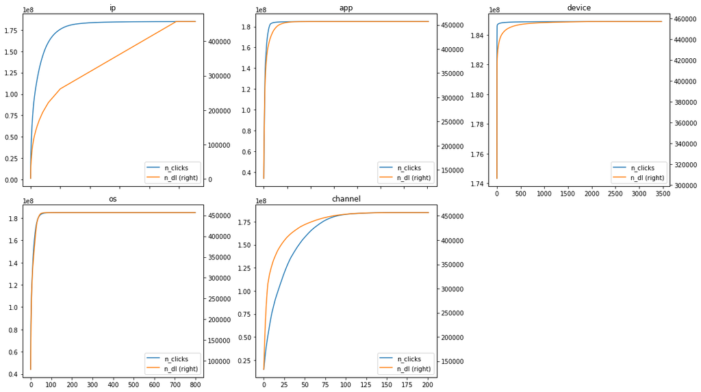

```python
cols = ['ip', 'app', 'device', 'os', 'channel']

print("Fig. 1 - Cumulative number of clicks and downloads in unique features:")
plt.figure(figsize=(16,9))
for idx, col in enumerate(cols):
    plt.subplot(2,3,idx+1)
    plt.title(col)
    df[col].value_counts().cumsum().sort_values().reset_index(drop=True).plot(legend=True, label = 'n_clicks')
    df.groupby(col)['is_attributed'].agg('sum').sort_values(ascending=False).cumsum().reset_index(drop=True).plot(secondary_y=True, legend=True, label = 'n_dl')
    plt.tight_layout()

gc.collect();
```

Notice from the graph that there are few `apps`, `devices` and `os` concentrating most clicks and downloads, while there is more variability in `ip` and `channel`. There is also some divergence in concentration of clicks and downloads in `ip`, `app`, `device` and `channel`, as follows:

IP:

- Clicks are more concentrated than downloads
- There are some IPs with many downloads (initial concavity)
- There are a lot of IPs with a single download (45 degree line segment)
- There are some IPs with no download (flat segment at the top/end)

App and Device:

- Clicks are more concentrated than downloads, so there a few are apps and devices with many clicks and low download rates.

Channel:

- Downloads are more concentrated than clicks; there are particular channels less prone to fraudulent clicks.

## Exploring clicks and downloads

Let's check how clicks and downloads vary within apps, devices, os and channels. Relevant questions:

- Which IP's concentrate most clicks? Do they have reasonable download rates?
- Which apps and devices have many clicks and low download rates?
- Which channels are less prone to fraudulent clicks?

### Exploring IPs

Which IP's concentrate most clicks? Do they have reasonable download rates?

```
Fig. 2 - Clicks and downloads by IP (%)
```

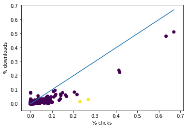

```python
tbl = df.groupby('ip')['is_attributed'].agg(['count', 'sum']).rename(columns={"count": "n_clicks", "sum": "n_dl"})
tbl['click_pct'] = tbl['n_clicks'] / tbl['n_clicks'].sum() * 100
tbl['dl_pct'] = tbl['n_dl'] / df['is_attributed'].sum() * 100

print("Fig. 2 - Clicks and downloads by IP (%)")
plt.scatter(tbl['click_pct'], tbl['dl_pct'], c = (tbl['click_pct'] > 0.2) & (tbl['dl_pct'] < 0.04))
plt.plot( [0, tbl[['click_pct', 'dl_pct']].max().max()],[0,tbl[['click_pct', 'dl_pct']].max().max()] )

plt.xlabel("% clicks")
plt.ylabel("% downloads")

del tbl
gc.collect();
```

No particular IP holds more than 1% of clicks nor downloads. There are two IPs with more than 0.20% of clicks and less 0.03% of downloads (on yellow). Number of clicks by IP might be a relevant feature.

#### Apps, devices, os, channels

- Which apps and devices have many clicks and low download rates?
- Which channels are less prone to fraudulent clicks?

```
Fig. 3 - Clicks and downloads by feature (%)
```

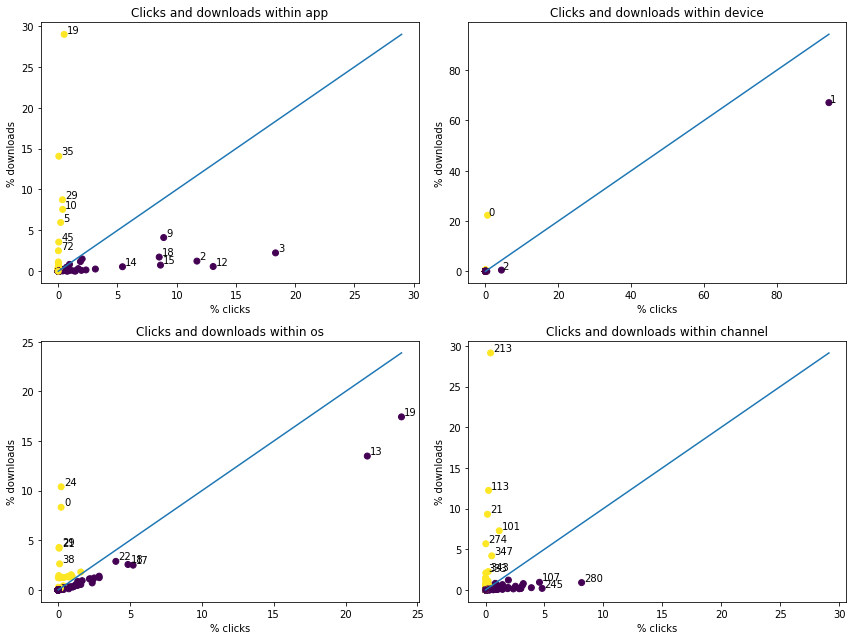

```python
print("Fig. 3 - Clicks and downloads by feature (%)")

plt.figure(figsize=(12, 9))

cols = ['app', 'device', 'os', 'channel']

for idx, col in enumerate(cols):
    tbl = df.groupby(col)['is_attributed'].agg(['count', 'sum']).rename(columns={"count": "n_clicks", "sum": "n_dl"}).reset_index()
    tbl['click_pct'] = tbl['n_clicks'] / tbl['n_clicks'].sum() * 100
    tbl['dl_pct'] = tbl['n_dl'] / df['is_attributed'].sum() * 100
    tbl.sort_values(by=['n_clicks'], ascending=False).head(10)

    plt.subplot(2,2,idx+1)
    plt.scatter(tbl['click_pct'], tbl['dl_pct'], c = tbl['dl_pct'] > tbl['click_pct'])
    plt.plot( [0, tbl[['click_pct', 'dl_pct']].max().max()],[0,tbl[['click_pct', 'dl_pct']].max().max()] )

    for i in tbl.index[(tbl['click_pct']>4) | (tbl['dl_pct'] > 2)].tolist():
        plt.annotate(str(tbl.loc[i, col]), (tbl['click_pct'][i]+0.2, tbl['dl_pct'][i]+0.2))

    plt.title("Clicks and downloads within " + col)
    plt.xlabel("% clicks")
    plt.ylabel("% downloads")
    plt.tight_layout()
```

If clicks and downloads were proportional, all points should lay over the 45 degrees line. The far down they are from the identity line, the more prone they are to fraudulent clicks. Conversely, far up from that line means more prone to downloading.

As an example, app 3 is likely to gather fraudulent clicks, while clicks on app 19 are more likely to result in a download.  
Only device 0 seems to be relevant for our purposes. There are some informative `os`.

Apps and channels are most informative. Let's combine their information in a new plot.

```
Fig. 4 - Clicks and downloads within apps and channels only
```

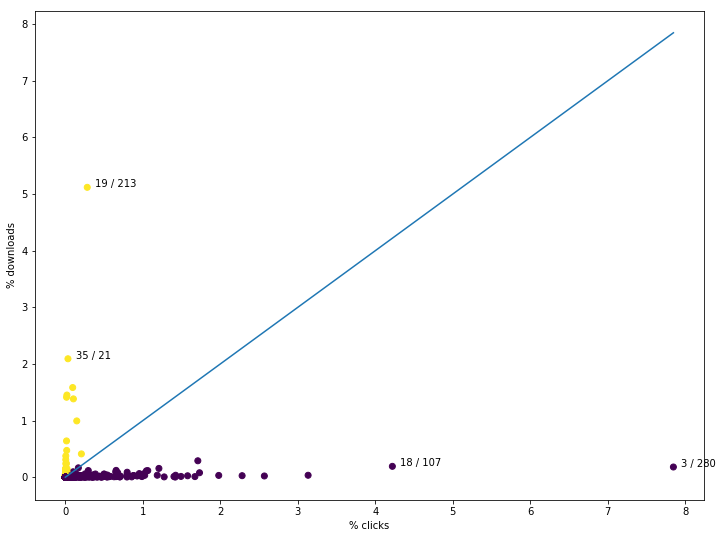

```python
plt.figure(figsize=(12,9))

tbl = df.sample(frac = 0.25) # fit in memory
tbl = tbl.groupby(['app', 'channel'])['is_attributed'].agg(['count', 'sum']).rename(columns={"count": "n_clicks", "sum": "n_dl"}).reset_index()
tbl['click_pct'] = tbl['n_clicks'] / tbl['n_clicks'].sum() * 100
tbl['dl_pct'] = tbl['n_dl'] / df['is_attributed'].sum() * 100

plt.scatter(tbl['click_pct'], tbl['dl_pct'], c = tbl['dl_pct'] > tbl['click_pct'])
plt.plot( [0, tbl[['click_pct', 'dl_pct']].max().max()],[0,tbl[['click_pct', 'dl_pct']].max().max()] )

print("Fig. 4 - Clicks and downloads within apps and channels only")
plt.xlabel("% clicks")
plt.ylabel("% downloads")

for i in tbl.index[(tbl['click_pct']>4) | (tbl['dl_pct'] > 2)].tolist():
    plt.annotate(str(tbl.loc[i, 'app']) + " / " + str(tbl.loc[i, 'channel']),
                 (tbl['click_pct'][i]+0.1, tbl['dl_pct'][i]))

del tbl
gc.collect();
```

Most relevant download rates:

```
- App 19, channel 213
- App 35, channel 21
```

Least relevant download rates:

```
- App 3, channel 280
- App 18, channel 107
```

Let's take a look at os and devices too.

```
Fig. 5 - Clicks and downloads within os and devices only
```

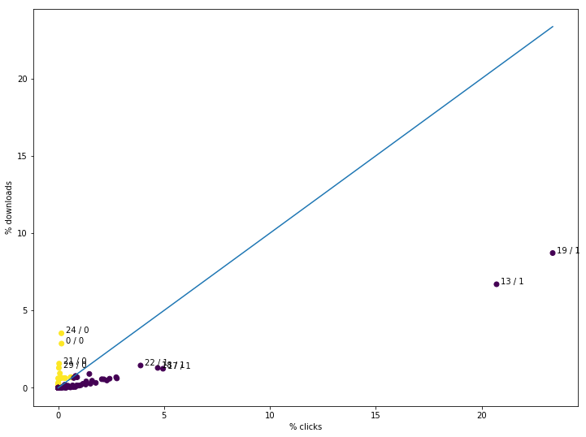

```python
plt.figure(figsize=(12,9))

tbl = df.sample(frac = 0.5) # fit in memory
tbl = tbl.groupby(['os', 'device'])['is_attributed'].agg(['count', 'sum']).rename(columns={"count": "n_clicks", "sum": "n_dl"}).reset_index()
tbl['click_pct'] = tbl['n_clicks'] / tbl['n_clicks'].sum() * 100
tbl['dl_pct'] = tbl['n_dl'] / df['is_attributed'].sum() * 100

plt.scatter(tbl['click_pct'], tbl['dl_pct'], c = tbl['dl_pct'] > tbl['click_pct'])
plt.plot( [0, tbl[['click_pct', 'dl_pct']].max().max()],[0,tbl[['click_pct', 'dl_pct']].max().max()] )

print("Fig. 5 - Clicks and downloads within os and devices only")
plt.xlabel("% clicks")
plt.ylabel("% downloads")

for i in tbl.index[(tbl['click_pct']>20) | (tbl['dl_pct'] > 1)].tolist():
    plt.annotate(str(tbl.loc[i, 'os']) + " / " + str(tbl.loc[i, 'device']),
                 (tbl['click_pct'][i]+0.2, tbl['dl_pct'][i]))

del tbl
gc.collect();
```

Most relevant download rates:

```
- os 24, device 0
- os 0, device 0
- os 21, device 0
- os 29, device 0
```

Device 0 is particulary important.

OS 13 and OS 19, with device 1, could also help to identify fraudulent clicks candidates.

### Exploring time

Let's check `click_time` now.

```python
df['day'] = df.click_time.dt.day.astype('uint16')
df['hour'] = df.click_time.dt.hour.astype('uint16')
df['day_hour'] = df['day'] * 100 + df['hour']
```

```
Fig. 6 - Clicks, downloads and download rate by day and hour
```

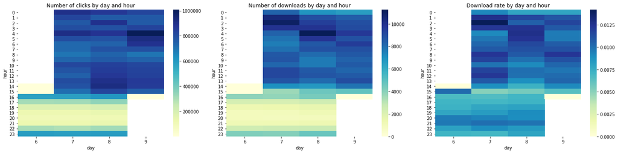

```python
print("Fig. 6 - Clicks, downloads and download rate by day and hour")

plt.figure(figsize=(20,5))

tbl = df.sample(frac=0.25)
tbl = tbl.groupby(['day', 'hour']).size().reset_index(name = "n")
plt.subplot(1,3,1)
plt.title("Number of clicks by day and hour")
sns.heatmap(tbl.pivot(index = 'hour', columns = 'day', values = 'n'), cmap="YlGnBu")

dls = df.groupby(['day', 'hour'])['is_attributed'].sum().reset_index(name = "dl")
plt.subplot(1,3,2)
plt.title("Number of downloads by day and hour")
sns.heatmap(dls.pivot(index = 'hour', columns = 'day', values = 'dl'), cmap="YlGnBu")

df_plot = pd.merge(tbl, dls)
df_plot['dl_rate'] = df_plot['dl'] / df_plot['n']
plt.subplot(1,3,3)
plt.title("Download rate by day and hour")
sns.heatmap(df_plot[['day', 'hour', 'dl_rate']].pivot(index = 'hour', columns = 'day', values = 'dl_rate'), cmap = "YlGnBu")

plt.tight_layout()

del tbl
df = df.drop(columns = ['day', 'hour'])
gc.collect();
```

Oddly, there are fewer clicks and downloads between 17:00 and 21:00 in our dataset. This might be due to sample selection by Kaggle's challenge admins.

On the third graph, we plot number of downloads per number of clicks. Download rate follows no clear pattern, in spite of the clear sazonality of clicks and downloads.

```
Fig. 7 - Number of clicks time series
```

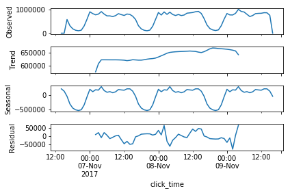

```python
from statsmodels.tsa.seasonal import seasonal_decompose

tbl = df.sample(frac=0.25)
tbl = tbl[['click_time', 'is_attributed']]
tbl = tbl.set_index('click_time')

tbl.index = tbl.index.floor(freq="H")
tbl = tbl.groupby(tbl.index)['is_attributed'].agg(['sum', 'count'])

print("Fig. 7 - Number of clicks time series")
res1 = seasonal_decompose(tbl['count'], model='additive', freq = 24)
fig1 = res1.plot()
```

```
Fig. 8 - Number of downloads time series
```

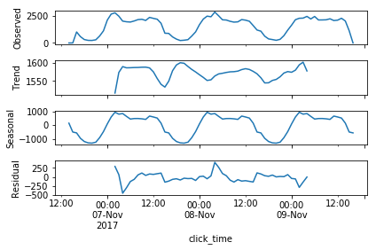

```python
print("Fig. 8 - Number of downloads time series")
res2 = seasonal_decompose(tbl['sum'], model='additive', freq = 24)
fig2 = res2.plot()
```

```
Fig. 9 - Download rate time series
```

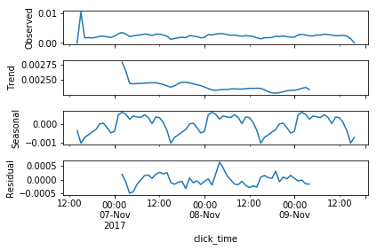

```python
print("Fig. 9 - Download rate time series")
res3 = seasonal_decompose(tbl['sum']/tbl['count'], model='additive', freq = 24)
fig3= res3.plot()

del tbl
gc.collect();
```

We see again from those graphs that, albeit the pattern in clicks and downloads, there is no clear time pattern in download rate.

# New features

Let's create some features based on what we've seen, and then create a simple model to test their importance.

```python
t = time.time()
print('Creating features by counting clicks...')

df = df.sample(frac = 0.1) # fit in memory

# Create feature identifying device 0 and drop 'device' column
df['device_0'] = (df['device'] == 0).astype('uint8')
df = df.drop(columns = 'device')

# Counting clicks
df['n_ip'] = df.groupby('ip')['ip'].transform('count')

df['n_ip_app'] = df.groupby(['ip', 'app'])['ip'].transform('count')
df['n_ip_ch'] = df.groupby(['ip', 'channel'])['ip'].transform('count')
df['n_ip_os'] = df.groupby(['ip', 'os'])['ip'].transform('count')

df['n_ip_app_ch'] = df.groupby(['ip', 'app', 'channel'])['ip'].transform('count')
df['n_ip_os_app_ch'] = df.groupby(['ip', 'os', 'app', 'channel'])['ip'].transform('count')

df['n_ip_day_hour'] = df.groupby(['ip', 'day_hour'])['ip'].transform('count')

# Interactions
df['app_channel'] = df['app'] * 1000 + df['channel']

elapsed = time.time() - t
print("Time creating features: %s seconds.\n" %round(elapsed))
```

```
Creating features by counting clicks...
Time creating features: 114 seconds.
```

```python
# Time features
t = time.time()
print('Creating features based on click_time...')

df = df.sort_values(by=['ip', 'click_time'])

df['ct_lag'] = df.groupby(['ip'])['click_time'].shift(1)
df['ct_lead'] = df.groupby(['ip'])['click_time'].shift(-1)

df['td_lag'] = df['click_time'] - df['ct_lag']
df = df.drop(columns = 'ct_lag')

df['td_lead'] = df['ct_lead'] - df['click_time']
df = df.drop(columns = 'ct_lead')

df['min_td'] = df[['td_lag', 'td_lead']].min(axis=1) / pd.Timedelta(hours=1)
df = df.drop(columns = ['td_lag', 'td_lead'])

df['min_td'].fillna(max(df.min_td), inplace = True)

df = df.drop(columns = ['ip', 'click_time'])
gc.collect();

elapsed = time.time() - t
print("Time creating features: %s seconds.\n" %round(elapsed))
```

```
Creating features based on click_time...
Time creating features: 64 seconds.
```

# Model

```python
# Preparing data to build a LightGBM model
t = time.time()
print('Preparing data to build a LightGBM model...')

from sklearn.cross_validation import train_test_split
import lightgbm as lgb

df_train = df.sample(frac = 0.8)
df_valid = df.sample(frac = 0.2)
del df
gc.collect();

y_train = df_train.is_attributed.values
y_valid = df_valid.is_attributed.values

df_train = df_train.drop('is_attributed', axis=1)
df_valid = df_valid.drop('is_attributed', axis=1)

categorical = ['app', 'os', 'channel', 'day_hour', 'device_0']
features = [col for col in df_train.columns]

lgb_train = lgb.Dataset(df_train, y_train, feature_name = features, categorical_feature=categorical, free_raw_data=False)
#del df_train
#del y_train
#gc.collect();

lgb_valid = lgb.Dataset(df_valid, y_valid, feature_name = features, categorical_feature=categorical, free_raw_data=False)
#del df_valid
#del y_valid
#gc.collect();

# specify your configurations as a dict
params = {
    'task': 'train',
    'boosting_type': 'gbdt',
    'objective': 'binary',
    'metric': 'auc',
    'num_leaves': 7,
    'max_depth': 3,
    'min_child_samples': 100,  # Minimum number of data need in a child(min_data_in_leaf)
    'max_bin': 100,  # Number of bucketed bin for feature values
    'learning_rate': 0.1,
    'feature_fraction': 0.9,
    'bagging_fraction': 0.8,
    'bagging_freq': 5,
    'verbose': 0,
    'scale_pos_weight': 99.74 # because training data is extremely unbalanced
}

elapsed = time.time() - t
print("Time elapsed: %s seconds.\n" %round(elapsed))
```

```
Preparing data to build a LightGBM model...
```

```
Time elapsed: 2 seconds.
```

```python
t = time.time()
print('Training LightGBM model...')
gbm = lgb.train(params,
               lgb_train,
               num_boost_round=500,
               valid_sets=lgb_valid,
               early_stopping_rounds=30,
               verbose_eval=False)
elapsed = time.time() - t
print("Time elapsed: %s minutes.\n" %round(elapsed/60))

gbm.best_score
```

```
Training LightGBM model...
```

```
Time elapsed: 0 minutes.
```

```
defaultdict(dict, {'valid_0': {'auc': 0.99371393902624}})
```

# Feature importance

```python
pd.set_option('display.max_rows', 25)
pd.DataFrame({'feature': features, 'importance': gbm.feature_importance()}).sort_values(by='importance', ascending=False)
```

[output not shown]

[figure not shown]

```python
import shap
shap.initjs()
preds = gbm.predict(df_train.iloc[:1000,:])
shap_values = gbm.predict(df_train.iloc[:1000,:], pred_contrib=True)
shap.summary_plot(shap_values, df_train.iloc[:1000,:])
```

This graph shows the impact of each feature in the model output. `channel`, `app`, `os`, and `day_hour` have the most impact on output, consistent with our variable importance table shown above.

Notice, for example, that while **low** number of clicks by a IP (`n_ip`) increases predicted download probability, **high** number of clicks by an IP in that particular App (`n_ip_app`) increases predicted download probability.

Also, if a click by an ip is distant in time from any other click of that same ip (as measured by `min_td`), then the model tends to predict higher download probability for that click.

Let's check how those features apply to a single example.

```python
shap.initjs()
shap.force_plot(shap_values[preds.argmax(),:], df_train.iloc[preds.argmax(),:], link="logit")
```

**Visualization omitted, Javascript library not loaded!**  
Have you run `initjs()` in this notebook? If this notebook was from another user you must also trust this notebook (File -> Trust notebook). If you are viewing this notebook on github the Javascript has been stripped for security.

Let's check another click to end our EDA.

```python
shap.initjs()
shap.force_plot(shap_values[preds.argmin(),:], df_train.iloc[preds.argmin():], link="logit")
```

**Visualization omitted, Javascript library not loaded!**  
Have you run `initjs()` in this notebook? If this notebook was from another user you must also trust this notebook (File -> Trust notebook). If you are viewing this notebook on github the Javascript has been stripped for security.

This is a click with 0% predicted download probability. Altough it features a high number of clicks (118) in that particular App, those clicks occurred in low download rate `os`, `channel`and `app`. Also, `min_td` indicates that this click also occurred shortly after another click by that same IP, further decreasing predicted download probability.